# Analysis of US loan data (2005-2014) by Christopher Buss

## Multivariate Plots Section

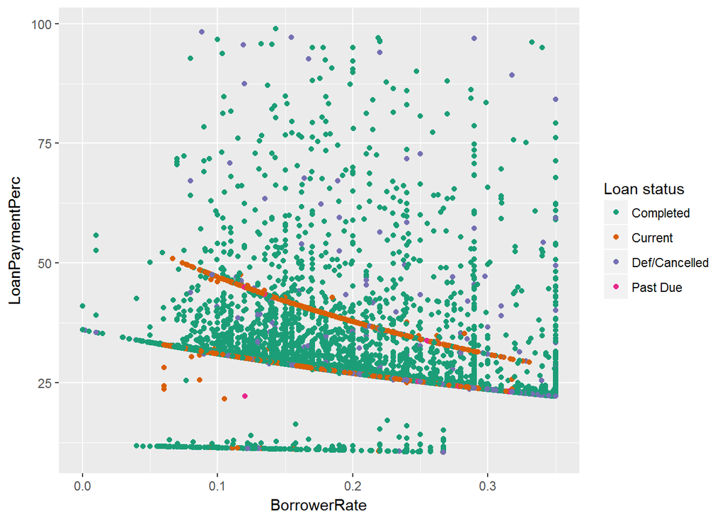

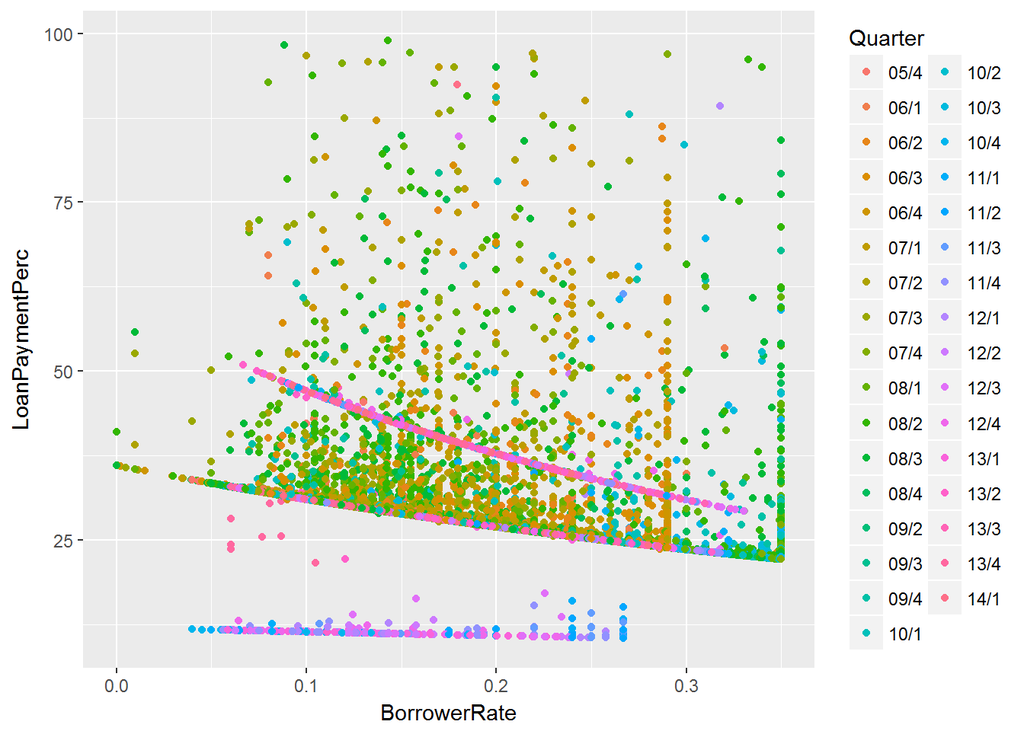

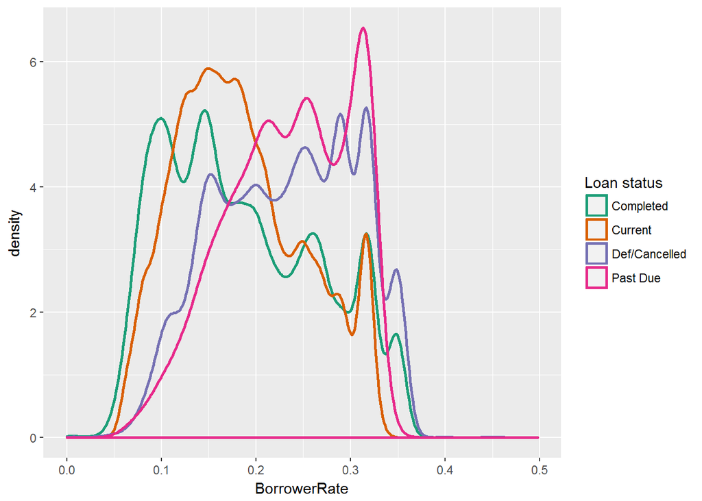

The interesting relationship between *BorrowerRate* and *LoanPaymentPerc* seem to be related to either the status of the loan or the quarter. Those data points on the “lines” in the plot are predominantly loans that are recent (2011 onwards) and current. Older, completed loans often diverge from this pattern.

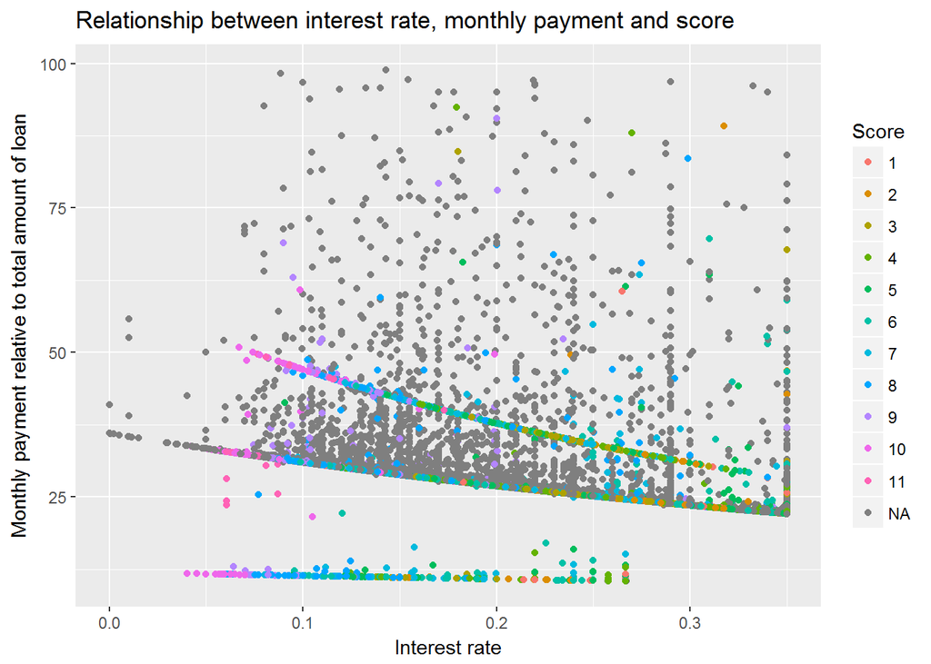

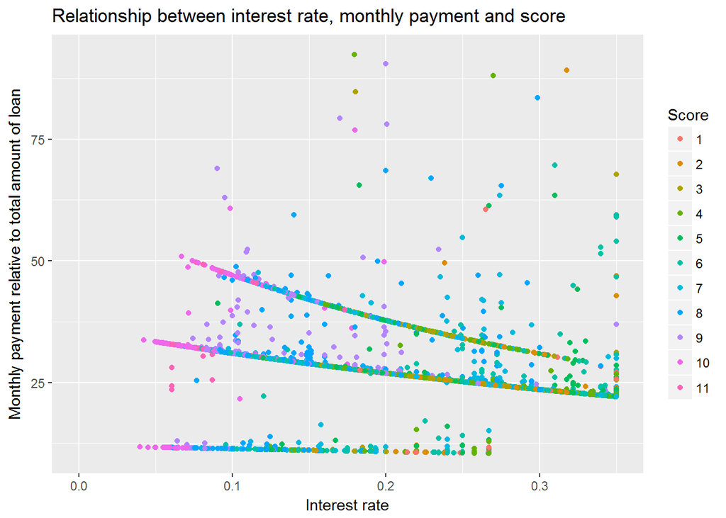

Apparently, *ProsperScores* are also related to the other two variables of interest. For all individuals with a score assigned, the monthly payment predicts the interest rate very well. This becomes apparent in the second plot - there are three straight lines. The reason for these three trajectories, however, remains unclear.

For individuals without a score (=earlier loans), there is much more dispersion of the interest rate.

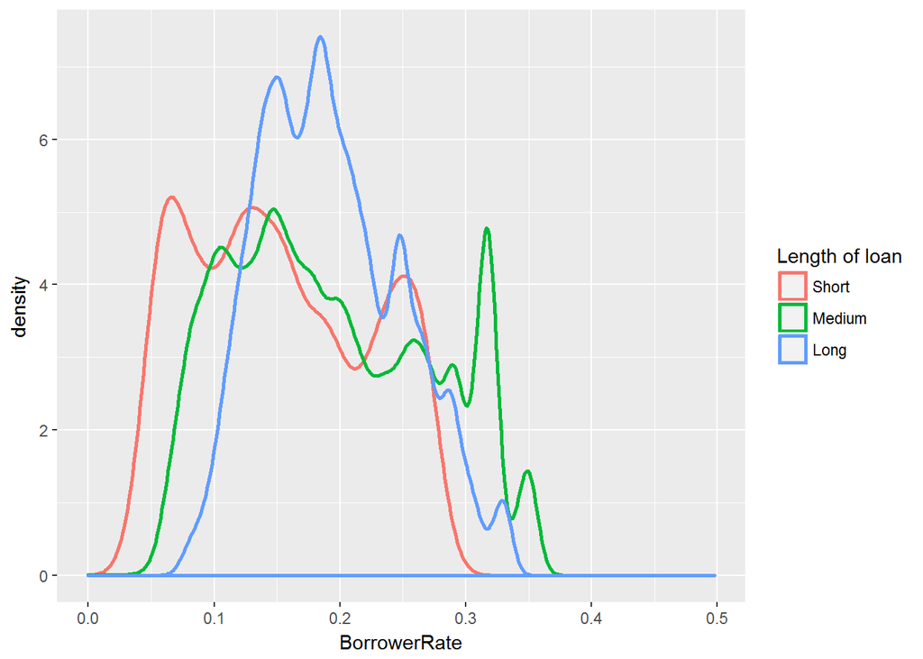

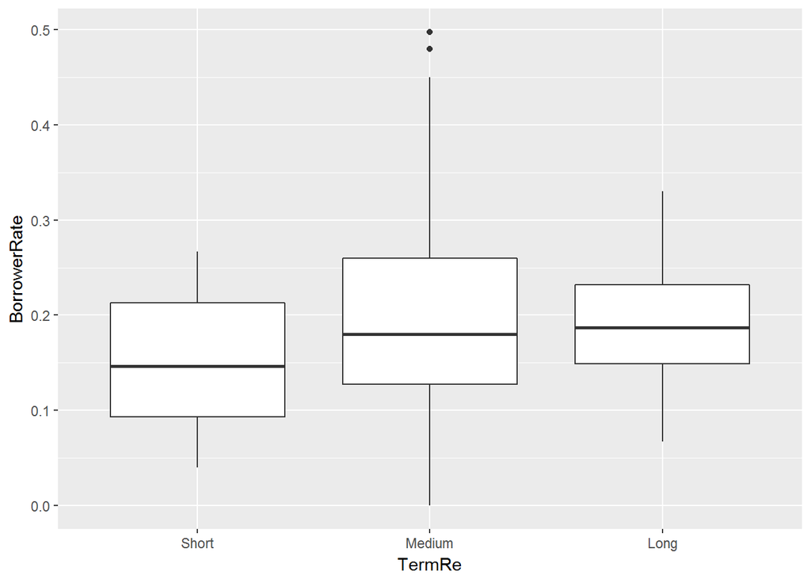

Another interesting pattern emerges when plotting the distribution of *BorrowerRate* across the legth of the loan. Borrower rates increase with term length, but the rates of medium-length loans are more dispersed.

## Linear regression analysis

```
##
## Calls:
## m1: lm(formula = df$BorrowerRate ~ df$ProsperScore)
## m2: lm(formula = df$BorrowerRate ~ df$ProsperScore + df$AmountLog)
## m3: lm(formula = df$BorrowerRate ~ df$ProsperScore + df$AmountLog +
##     df$IncomeLog)
##
## ===================================================================
##                          m1              m2              m3
## -------------------------------------------------------------------
##   (Intercept)            0.317***        0.564***        0.582***
##                         (0.001)         (0.002)         (0.002)
##   df$ProsperScore       -0.020***       -0.018***       -0.018***
##                         (0.000)         (0.000)         (0.000)
##   df$AmountLog                          -0.029***       -0.028***
##                                         (0.000)         (0.000)
##   df$IncomeLog                                          -0.004***
##                                                         (0.000)
## -------------------------------------------------------------------
##   R-squared              0.422           0.500           0.502
##   adj. R-squared         0.422           0.500           0.502
##   sigma                  0.057           0.053           0.053
##   F                  61544.088       42206.417       28386.802
##   p                      0.000           0.000           0.000
##   Log-likelihood    122468.684      128610.058      128796.717
##   Deviance             270.630         233.955         232.921
##   AIC              -244931.369     -257212.116     -257583.434
##   BIC              -244903.341     -257174.745     -257536.721
##   N                  84344           84344           84344
## ===================================================================
```

```
##
## Calls:
## m4: lm(formula = df$BorrowerRate ~ df$ProsperScore + df$AmountLog +
##     df$IncomeLog + df$LoanPaymentPerc)
## m5: lm(formula = df$BorrowerRate ~ df$ProsperScore + df$AmountLog +
##     df$IncomeLog + df$LoanPaymentPerc + df$TermRe)
## m6: lm(formula = df$BorrowerRate ~ df$ProsperScore + df$AmountLog +
##     df$IncomeLog + df$LoanPaymentPerc + df$TermRe + df$DebtToIncomeRatio)
##
## ===========================================================================
##                                  m4              m5              m6
## ---------------------------------------------------------------------------
##   (Intercept)                    0.564***        0.466***        0.433***
##                                 (0.002)         (0.002)         (0.002)
##   df$ProsperScore               -0.017***       -0.005***       -0.005***
##                                 (0.000)         (0.000)         (0.000)
##   df$AmountLog                  -0.020***       -0.012***       -0.013***
##                                 (0.000)         (0.000)         (0.000)
##   df$IncomeLog                  -0.004***       -0.001***        0.003***
##                                 (0.000)         (0.000)         (0.000)
##   df$LoanPaymentPerc            -0.002***       -0.016***       -0.016***
##                                 (0.000)         (0.000)         (0.000)
##   df$TermRe: Medium/Short                        0.298***        0.302***
##                                                 (0.001)         (0.001)
##   df$TermRe: Long/Short                          0.478***        0.483***
##                                                 (0.001)         (0.001)
##   df$DebtToIncomeRatio                                           0.006***
##                                                                 (0.000)
## ---------------------------------------------------------------------------
##   R-squared                      0.523           0.827           0.830
##   adj. R-squared                 0.523           0.827           0.830
##   sigma                          0.051           0.031           0.030
##   F                          23125.975       67130.392       53835.566
##   p                              0.000           0.000           0.000
##   Log-likelihood            130585.581      173317.251      159931.030
##   Deviance                     223.248          81.046          71.230
##   AIC                      -261159.163     -346618.502     -319844.061
##   BIC                      -261103.107     -346543.760     -319760.786
##   N                          84344           84344           77094
## ===========================================================================
```

# Multivariate Analysis

### Talk about some of the relationships you observed in this part Were there any interesting or surprising interactions between features?

There is an interesting relationship between *ProsperScore*, *LoanPaymentPerc* and *BorrowerRate*. For the most recent loans, *LoanPaymentPerc* is a very good predictor for *BorrowerRate*. For older loans, the relationship us much weaker.

### Did you create any models with your dataset? Discuss limitations!

I calculated a linear regression model with the *interest rate* as dependent variable, and *ProsperScore*, *AmountLog*, *IncomeLog*, *LoanPaymentPerc*, *TermRe* and *DebtToIncomeRatio* as independent variables.

Some other variables in the dataset related to the credit history of the person could be of interest. Another limitation is that these results indicate correlation, but not causation.

# Final Plots and Summary

### Plot One

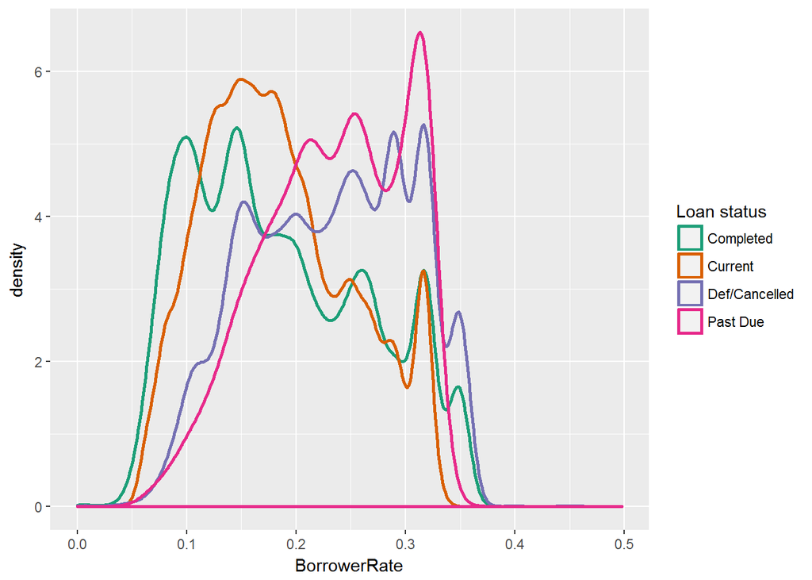

### Description One

This plot shows the distribution of the *BorrowerRate* for the four different status. It becomes apparent that on the one hand completed/current loans and on the other hand defaulted/past due loans have a different distribution. For the former, *BorrowerRate* is usually lower.

The direction of causality, however, is unclear. It might be that individuals with lower rates default less often, or that defaulting the loan leads to increased rates.

### Plot Two

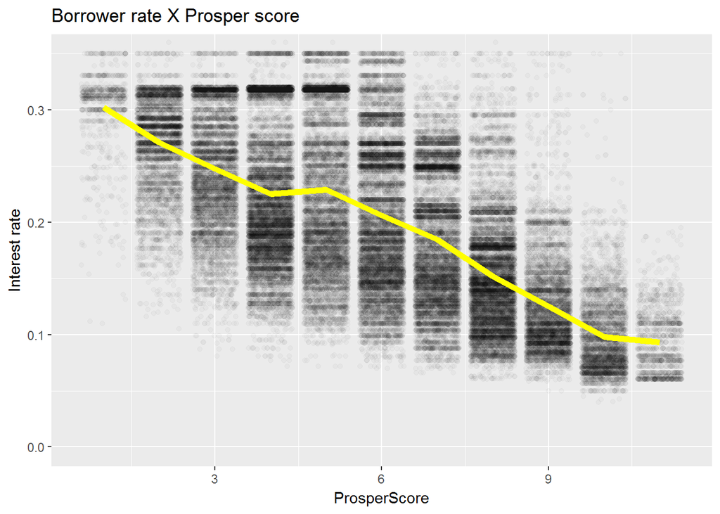

### Description Two

The relationship between *BorrowerRate* and *ProsperScore* is further illustrated with this plot. While there is still some variability in the data, there is a clear downward trend of the interest rate in case of better scores.

### Plot Three

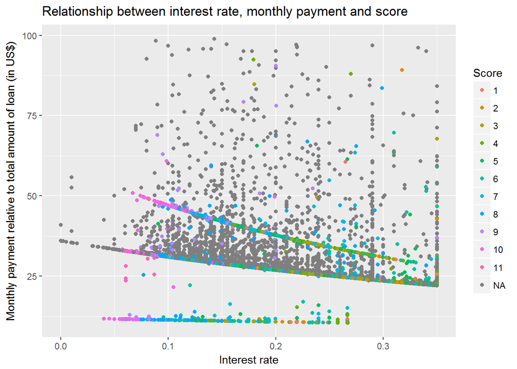

### Description Three

The third plot visualizes the relationship between interest rate, monthly payment and score. For all individuals with a score assigned (data points not in grey), the monthly payment describes the interest rate very well. There are three “lines” with different trajectories. For each of these trajectories, there is a nearly perfect correlation between the monthly payment and the interest rate. The color gradient of the line indicates that the factor score is another important determinant of interest rates.

However, two questions remain open. First, why do data points with NA on the factor score deviate so much from this pattern? The reason might be that interest rates are calculated in a different way when no score is availabe to the lender. Second, why are there three different trajectories? It is likely that a fourth independent variable is responsible for this.

# Reflection

Overall, the results are not surprising - the interest rate largely depends on the credibility of the borrower and the characteristics of the loan. I am still puzzled by Plot 3 in my summary. I cannot explain the pattern in this graph, but I assume that the interest rate is calculated differently for old (completed) loans than for newer (current) loans. However, this point needs further exploration.

I did struggle a bit with the R-syntax at times because I am a genuine user of STATA. In particular, I had to use some workarounds to make the plots over time work. However, the graph functions in R a really nice!

Future analysis of the dataset could explore the following points: * How can be predict if a borrower defaults on a loan? * Are there regional differences between states? * How can we predict someone’s ProsperScore?